# AM14_GA1

Group 10

1/10/2022

## Load libraries

```r
library(ggplot2)
library(dplyr)
library(tidyverse)
library(readxl)
library(lubridate)
library(skimr)
library(moments)
```

## Question 1

Load the monthly stock data. We will also load the daily stock data, which we’ll need later in the assignment.

```r
# Read in the monthly data using the 'read_excel' function:
monthly_data <- read_excel("PS1_Monthly.xlsx") %>%
  # Perform an initial cleaning of the names in the dataset.
  janitor::clean_names() %>%
  # Mutate and transform dates stored in character/numeric vectors to Date objects
  mutate(date = ymd(date))

# Skim the data - this allows us to view specific summary statistics
skimr::skim(monthly_data)
```

Data summary

| Name | monthly_data |
| --- | --- |
| Number of rows | 1817 |
| Number of columns | 18 |
| _______________________ |  |
| Column type frequency: |  |
| character | 3 |
| Date | 1 |
| numeric | 14 |
| ________________________ |  |
| Group variables | None |

**Variable type: character**

| skim_variable | n_missing | complete_rate | min | max | empty | n_unique | whitespace |
| --- | --- | --- | --- | --- | --- | --- | --- |
| ticker | 0 | 1 | 1 | 4 | 0 | 12 | 0 |
| comnam | 0 | 1 | 10 | 24 | 0 | 13 | 0 |
| primexch | 0 | 1 | 1 | 1 | 0 | 2 | 0 |

**Variable type: Date**

| skim_variable | n_missing | complete_rate | min | max | median | n_unique |
| --- | --- | --- | --- | --- | --- | --- |
| date | 0 | 1 | 1989-12-29 | 2014-12-31 | 2002-06-28 | 301 |

**Variable type: numeric**

| skim_variable | n_missing | complete_rate | mean | sd | p0 | p25 | p50 | p75 | p100 | hist |
| --- | --- | --- | --- | --- | --- | --- | --- | --- | --- | --- |
| permno | 0 | 1.00 | 35409.03 | 24874.21 | 10107.00 | 11850.00 | 47896.00 | 59328.00 | 70519.00 | ▇▁▁▃▆ |
| divamt | 1256 | 0.31 | 0.28 | 0.24 | 0.00 | 0.11 | 0.23 | 0.40 | 3.00 | ▇▁▁▁▁ |
| facpr | 1256 | 0.31 | 0.04 | 0.20 | -0.90 | 0.00 | 0.00 | 0.00 | 2.00 | ▁▇▁▁▁ |
| prc | 0 | 1.00 | 52.04 | 28.24 | 1.50 | 29.76 | 46.36 | 69.25 | 175.00 | ▇▇▃▁▁ |
| ret | 0 | 1.00 | 0.01 | 0.09 | -0.58 | -0.03 | 0.01 | 0.06 | 0.69 | ▁▁▇▁▁ |
| bid | 149 | 0.92 | 52.34 | 28.57 | 1.41 | 29.81 | 46.23 | 70.02 | 174.94 | ▇▇▃▁▁ |
| ask | 149 | 0.92 | 52.49 | 28.65 | 1.42 | 29.82 | 46.40 | 70.20 | 175.00 | ▆▇▃▁▁ |
| cfacpr | 0 | 1.00 | 4.64 | 11.51 | 0.10 | 1.00 | 1.00 | 3.00 | 144.00 | ▇▁▁▁▁ |
| retx | 0 | 1.00 | 0.01 | 0.09 | -0.58 | -0.04 | 0.01 | 0.06 | 0.69 | ▁▁▇▁▁ |
| vwretd | 0 | 1.00 | 0.01 | 0.04 | -0.18 | -0.02 | 0.01 | 0.04 | 0.11 | ▁▁▃▇▂ |
| vwretx | 0 | 1.00 | 0.01 | 0.04 | -0.19 | -0.02 | 0.01 | 0.04 | 0.11 | ▁▁▃▇▂ |
| ewretd | 0 | 1.00 | 0.01 | 0.05 | -0.21 | -0.02 | 0.02 | 0.04 | 0.23 | ▁▂▇▂▁ |
| ewretx | 0 | 1.00 | 0.01 | 0.05 | -0.21 | -0.02 | 0.01 | 0.04 | 0.22 | ▁▂▇▂▁ |
| sprtrn | 0 | 1.00 | 0.01 | 0.04 | -0.17 | -0.02 | 0.01 | 0.03 | 0.11 | ▁▁▅▇▂ |

The “PS1_Monthly” data contains information related to the stocks for the following unique companies.

```r
# Output all the unique company names
print(unique(monthly_data$comnam))
```

```
##  [1] "MICROSOFT CORP"           "EXXON CORP"
##  [3] "EXXON MOBIL CORP"         "GENERAL ELECTRIC CO"
##  [5] "CHEMICAL BANKING CORP"    "CHASE MANHATTAN CORP NEW"
##  [7] "J P MORGAN CHASE & CO"    "JPMORGAN CHASE & CO"
##  [9] "INTEL CORP"               "PRIMERICA CORP NEW"
## [11] "TRAVELERS INC"            "TRAVELERS GROUP INC"
## [13] "CITIGROUP INC"
```

## Question 2

For this question, we use the holding period returns to create a total return index for MSFT + GE stocks, as well as the S&P500 index. We compare the returns where dividends are reinvested, against the returns without dividends for each of these stocks/indices.

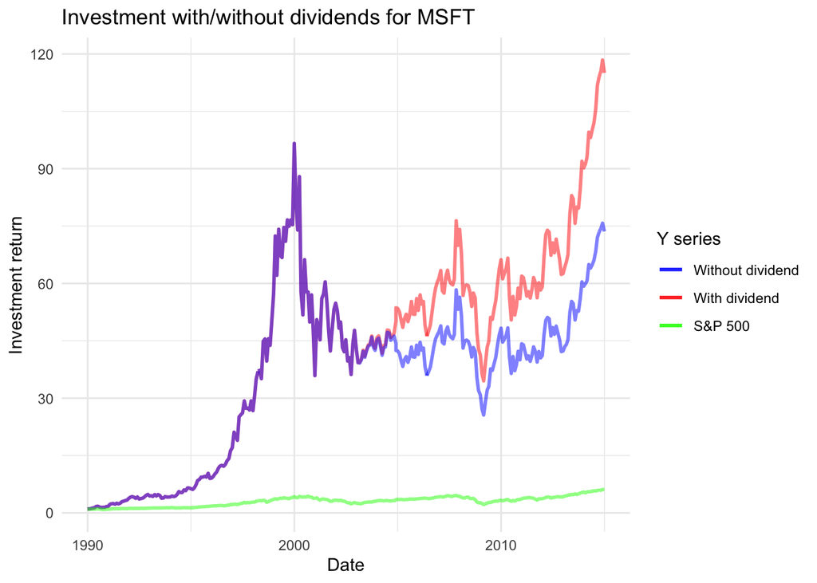

```r
# Create variable 'question2' which contains the relevant stocks
question2 <- c('MSFT', 'GE')

# Create a new variable 'monthly_q2' for determining the returns.
monthly_q2 <- monthly_data %>%
  # Use 'question2' variable to filter out for 'MSFT' and 'GE'
  filter(ticker %in% question2) %>%
  # Group the two tickers above
  group_by(ticker) %>%
  # Mutate new columns for the returns (+1)
  mutate(ret1 = ret+1,
         retx1 = retx +1,
         sprtrn1 = sprtrn +1) %>%
  # Mutate for the cumulative product of the previous variables to work out the
  # the inverse returns - inv_ret accounts for  stock returns with dividends,
  # inv_retx accounts for stock returns without dividends, whilst inv_sprtrn
  # accounts for S&P500 returns.
  mutate(inv_ret = cumprod(ret1),
         inv_retx = cumprod(retx1),
         inv_sprtrn = cumprod(sprtrn1)) %>%
  # Remove the dummy variables
  select(-ret1,-retx1,-sprtrn1)


# Call monthly_q2 variable for plotting - we first plot MSFT
monthly_q2 %>%
  # Filter for MSFT
  filter(ticker == "MSFT") %>%
  # Initialise ggplot
  ggplot() +
  # Plot lines for MSFT returns with dividends and without dividends
  geom_line(aes(x = date, y=inv_ret, color="With dividend"), alpha = 0.5, size = 1)+
  geom_line(aes(x = date, y=inv_retx, color="Without dividend"),alpha = 0.5, size = 1)+
  # Add a line plot for the S&P500 returns
  geom_line(aes(x = date, y=inv_sprtrn, color="S&P 500"),alpha = 0.5, size = 1)+
  # Set theme for the plot
  theme_minimal()+
  # Assign labels
  labs(title="Investment with/without dividends for MSFT",
    y="Investment return",
    x="Date")+
  # Assign colours to the keys
  scale_color_manual(name = "Y series", values = c("Without dividend" = "blue", "With dividend" = "red","S&P 500" = "green"))
```

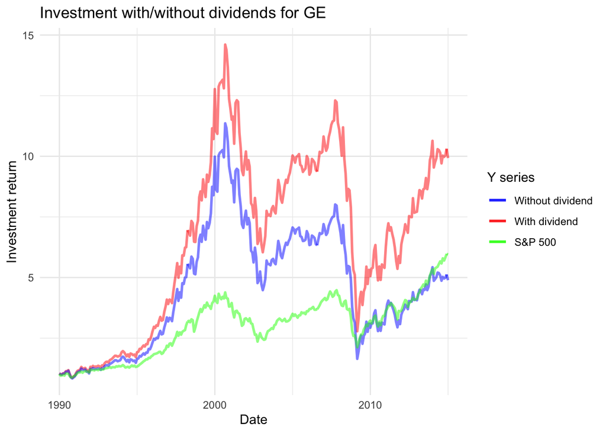

```r
# Call monthly_q2 variable for plotting GE
monthly_q2 %>%
  # Filter out for GE stock
  filter(ticker == "GE") %>%
  # Initialise ggplot
  ggplot() +
  # Use the geom_line function to plot GE returns with and without dividends
  geom_line(aes(x = date, y=inv_ret, color="With dividend"), alpha = 0.5, size = 1)+
  geom_line(aes(x = date, y=inv_retx, color="Without dividend"),alpha = 0.5, size = 1)+
  # Create a line plot of the S&P500 for comparison
  geom_line(aes(x = date, y=inv_sprtrn, color="S&P 500"),alpha = 0.5, size = 1)+
  # Set theme for the plot
  theme_minimal()+
  # Apply lables to this second plot
  labs(title="Investment with/without dividends for GE",
    y="Investment return",
    x="Date")+
  # Assign colours to corresponding lines
  scale_color_manual(name = "Y series", values = c("Without dividend" = "blue", "With dividend" = "red","S&P 500" = "green"))
```

As we can see, the peaks and troughs for all plots are somewhat aligned. This shows that all of these stocks/indices follow similar behavioral + investing trends. As expected, we can also see that the investment returns **with** dividends will be higher than those **without** dividends.

## Question 3

Here, we generate a new variable that contains log returns (LRET) - we calculate sample statistics for these log returns and then plot the normal returns against the log returns for “MSFT”.

```r
monthly_log <- monthly_data %>%
  # Create a log return column 'lret' which takes the log of the return
  mutate(lret = log(1+ret))

# Create a new dataframe for the summary statistics we calculate
sum_table_monthly <- monthly_log %>%
  #filter for stocks we want to calculate statistics for
  filter(ticker %in% question2) %>%
  # Group by the ticker so we can calculate statistics for each one
  group_by(ticker) %>%
  # Use the summarise function to calculate different sample statistics
  summarise(ret_mean = mean(ret),
            logret_mean = mean(lret, na.rm = TRUE),
            ret_var = var(ret),
            logret_var = var(lret, na.rm = TRUE),
            ret_skew = skewness(ret),
            logret_skew = skewness(lret, na.rm = TRUE),
            ret_kur = kurtosis(ret),
            logret_kur = kurtosis(lret, na.rm = TRUE))

sum_table_monthly
```

```
## # A tibble: 2 × 9
##   ticker ret_mean logret_mean ret_var logret_var ret_skew logret_skew ret_kur
##   <chr>     <dbl>       <dbl>   <dbl>      <dbl>    <dbl>       <dbl>   <dbl>
## 1 GE       0.0103     0.00763 0.00521    0.00528   -0.184      -0.594    4.52
## 2 MSFT     0.0200     0.0157  0.00866    0.00828    0.444      -0.102    5.04
## # … with 1 more variable: logret_kur <dbl>
```

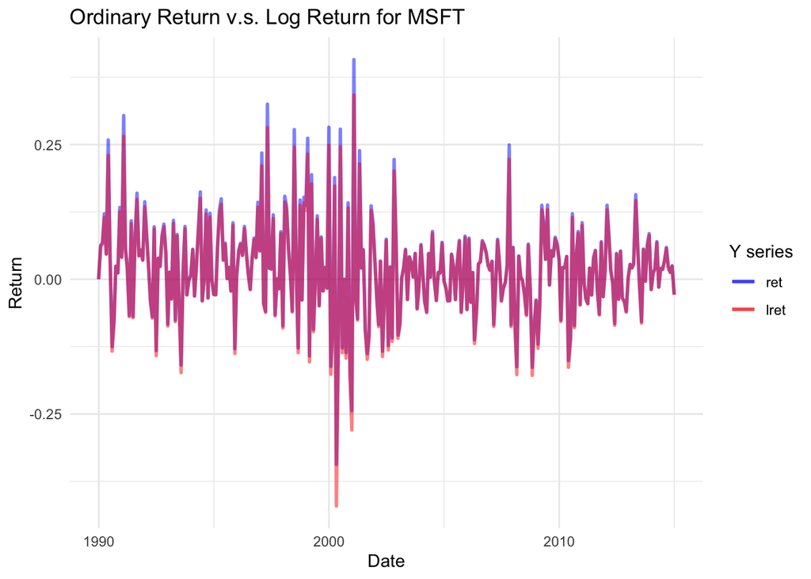

```r
monthly_log %>%
  # Filter out "MSFT" from our 'monthly log' dataframe so that we can plot
  filter(ticker == "MSFT") %>%
  # Call ggplot
  ggplot() +
  # Create line plots for both log returns and normal returns - differentiated by colour
  geom_line(aes(x= date, y=ret, color="ret"), alpha = 0.5, size = 1)+
  geom_line(aes(x= date, y=lret, color="lret"), alpha = 0.5, size = 1)+
  # Set the figure theme
  theme_minimal()+
  # Apply labels to the plot
  labs(title="Ordinary Return v.s. Log Return for MSFT",
    y="Return",
    x="Date")+
  # Assign the appropraite colours to the plot and its legend
  scale_color_manual(name = "Y series", values = c("ret" = "blue", "lret" = "red"))
```

# Question 4

In this section we download the data from the PS1_Daily.xlsx file - this contains two separate sheets - the first ’HPR_daily" is **imported below** and contains the daily holding period for the 6 stocks.

```r
# Use the read_excel function to import page 1 from the excel file
daily_data <- read_excel("PS1_Daily.xlsx", sheet = "HPR_daily", skip = 1) %>%
  # Do an initial cleaning of the names in the dataset
  janitor::clean_names()%>%
  # Overwrite the date variable - transform dates stored in character/numeric
  # vectors to Date objects
  mutate(date = ymd(date))

# Skim the data to view certain summary statistics
skimr::skim(daily_data)
```

Data summary

| Name | daily_data |
| --- | --- |
| Number of rows | 6301 |
| Number of columns | 9 |
| _______________________ |  |
| Column type frequency: |  |
| Date | 1 |
| numeric | 8 |
| ________________________ |  |
| Group variables | None |

**Variable type: Date**

| skim_variable | n_missing | complete_rate | min | max | median | n_unique |
| --- | --- | --- | --- | --- | --- | --- |
| date | 0 | 1 | 1990-01-02 | 2014-12-31 | 2002-06-27 | 6301 |

**Variable type: numeric**

| skim_variable | n_missing | complete_rate | mean | sd | p0 | p25 | p50 | p75 | p100 | hist |
| --- | --- | --- | --- | --- | --- | --- | --- | --- | --- | --- |
| msft | 0 | 1 | 0 | 0.02 | -0.16 | -0.01 | 0 | 0.01 | 0.20 | ▁▂▇▁▁ |
| xom | 0 | 1 | 0 | 0.01 | -0.14 | -0.01 | 0 | 0.01 | 0.17 | ▁▁▇▁▁ |
| ge | 0 | 1 | 0 | 0.02 | -0.13 | -0.01 | 0 | 0.01 | 0.20 | ▁▇▆▁▁ |
| jpm | 0 | 1 | 0 | 0.03 | -0.21 | -0.01 | 0 | 0.01 | 0.25 | ▁▁▇▁▁ |
| intc | 0 | 1 | 0 | 0.02 | -0.22 | -0.01 | 0 | 0.01 | 0.20 | ▁▁▇▁▁ |
| c | 0 | 1 | 0 | 0.03 | -0.39 | -0.01 | 0 | 0.01 | 0.58 | ▁▆▇▁▁ |
| vwretd | 0 | 1 | 0 | 0.01 | -0.09 | 0.00 | 0 | 0.01 | 0.11 | ▁▂▇▁▁ |
| sprtrn | 0 | 1 | 0 | 0.01 | -0.09 | 0.00 | 0 | 0.01 | 0.12 | ▁▂▇▁▁ |

# Question 5

In this question, we construct a daily total return index for the ‘MSFT’ and ‘GE’ stocks, as well as the S&P500. This allows us to compare the daily total returns index with the monthly total returns index (determined in Q2).

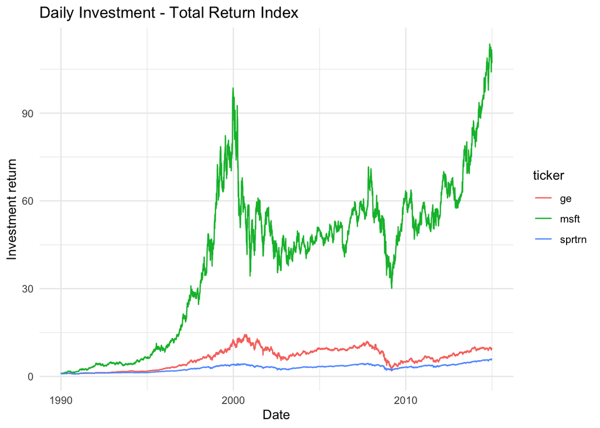

```r
# Assign a new variable that will enable us to filter the data
question5 <- c('msft', 'ge', "sprtrn")

# Create a new dataframe from which the daily total return index will be determined
daily_q5 <- daily_data %>%
  # Use the pivot longer function 'lengthen the data' - this makes it easier to
  # filter and plot the data
  pivot_longer(!date, names_to = "ticker", values_to = "ret") %>%
  # We filter for the appropriate stocks
  filter(ticker %in% question5) %>%
  # Group the data by the relevant stocks
  group_by(ticker) %>%
  # Arrange the data by stock + within that, arrange the data by date.
  arrange(ticker,date) %>%
  # Mutate new column with the returns (ret + 1)
  mutate(ret1 = ret+1) %>%
  # Determine the inverse return by finding the cumulative product of ret1
  mutate(inv_ret = cumprod(ret1)) %>%
  # Remove the dummy variables
  select(-ret1)

# Call the new variable so that we can make the plot
daily_q5 %>%
  # Call ggplot and assign the axes, group and color
  ggplot(aes(x = date, y=inv_ret, group=ticker, color=ticker)) +
  # Use geom_line to plot the data
  geom_line()+
  # Set the theme of the plot
  theme_minimal()+
  # Set the labels for the plot
  labs(title="Daily Investment - Total Return Index",
    y="Investment return",
    x="Date")
```

# Question 6

```r
#Create new dataframe in which we will use the pivot longer filter to transform the original data. This will make it easier to do our calculations.
daily_log <-daily_data %>%
  pivot_longer(!date,names_to = "ticker",values_to = "ret") %>%
  #Calculate log returns
  mutate(lret = log(1+ret))

sum_table_daily <-  daily_log %>%
  #Filter out stocks we don't need
  filter(ticker %in% question5) %>%
  group_by(ticker) %>%
  #Calculate all of our summary statistics
  summarise(ret_mean = mean(ret),
            logret_mean = mean(lret, na.rm = TRUE),
            ret_var = var(ret),
            logret_var = var(lret, na.rm = TRUE),
            ret_skew = skewness(ret),
            logret_skew = skewness(lret, na.rm = TRUE),
            ret_kur = kurtosis(ret),
            logret_kur = kurtosis(lret, na.rm = TRUE))
sum_table_daily
```

```
## # A tibble: 3 × 9
##   ticker ret_mean logret_mean  ret_var logret_var ret_skew logret_skew ret_kur
##   <chr>     <dbl>       <dbl>    <dbl>      <dbl>    <dbl>       <dbl>   <dbl>
## 1 ge     0.000517    0.000356 0.000323   0.000323   0.286      0.00496   11.9
## 2 msft   0.000958    0.000742 0.000433   0.000431   0.250      0.0135     8.80
## 3 sprtrn 0.000345    0.000280 0.000130   0.000130  -0.0563    -0.240     11.9
## # … with 1 more variable: logret_kur <dbl>
```

## Question 7

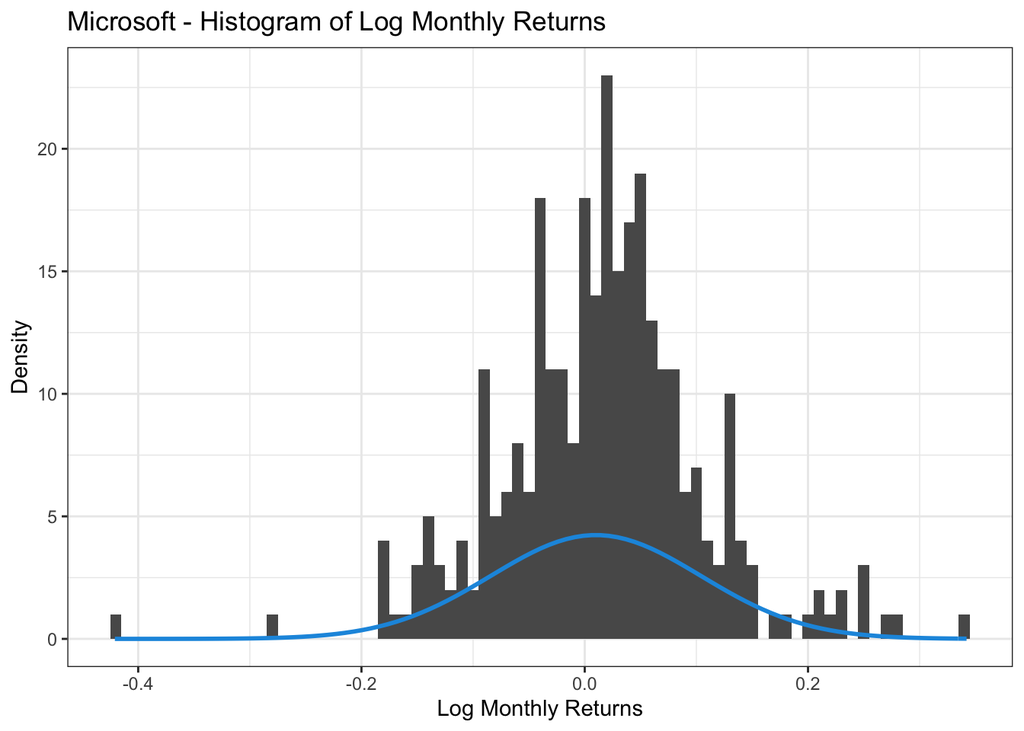

```r
#Plot the monthly log returns for MSFT
monthly_log %>%
  filter(ticker == "MSFT") %>%
  select(lret) %>%
  ggplot(aes(x = lret)) +
  geom_histogram(binwidth = 0.01) +
  stat_function(fun = dnorm,
                args = list(mean = mean(monthly_log$lret),
                            sd = sd(monthly_log$lret)),
                col = "#1b98e0",
                size = 1) +
  theme_bw() +
  labs(
    title = "Microsoft - Histogram of Log Monthly Returns",
    x = "Log Monthly Returns",
    y = "Density"
  )
```

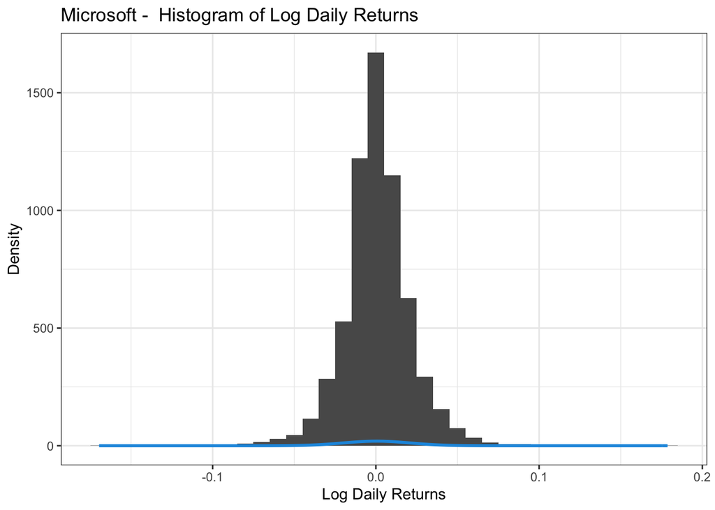

```r
#Plot the daily log returns for MSFT
daily_log %>%
  filter(ticker == "msft") %>%
  ggplot(aes(x = lret)) +
  geom_histogram(binwidth = 0.01) +
  stat_function(fun = dnorm,
                args = list(mean = mean(daily_log$lret),
                            sd = sd(daily_log$lret)),
                col = "#1b98e0",
                size = 1) +
  theme_bw() +
  labs(
    title = "Microsoft -  Histogram of Log Daily Returns",
    x = "Log Daily Returns",
    y = "Density"
  )
```

While both graphs are leptokurtic, which means they have more values centered around the mean, ie. higher bell, daily log returns by far have the highest kurtosis. Monthly log returns also have more outliers than daily returns.

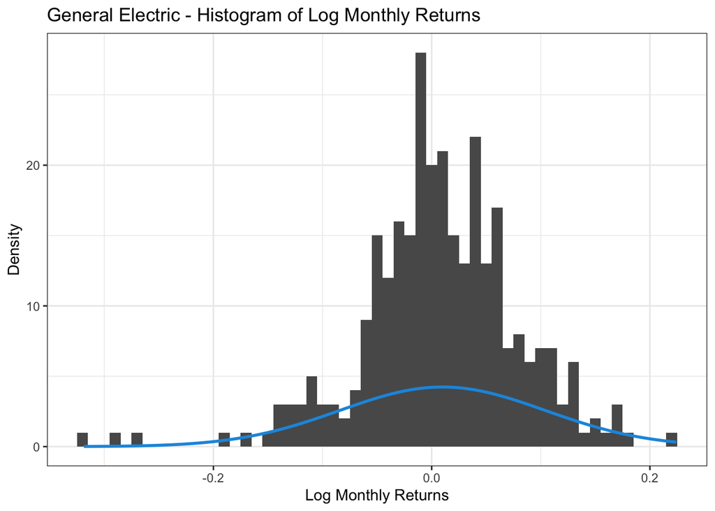

```r
#Plot the monthly log returns for GE
monthly_log %>%
  filter(ticker == "GE") %>%
  select(lret) %>%
  ggplot(aes(x = lret)) +
  geom_histogram(binwidth = 0.01) +
  stat_function(fun = dnorm,
                args = list(mean = mean(monthly_log$lret),
                            sd = sd(monthly_log$lret)),
                col = "#1b98e0",
                size = 1) +
  theme_bw() +
  labs(
    title = "General Electric - Histogram of Log Monthly Returns",
    x = "Log Monthly Returns",
    y = "Density"
  )
```

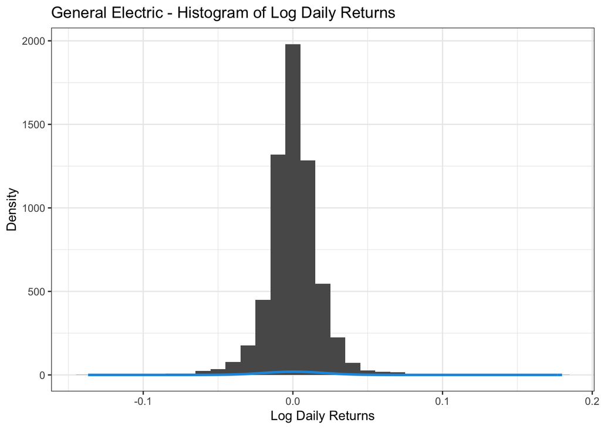

```r
#Plot the daily log returns for GE
daily_log %>%
  filter(ticker == "ge") %>%
  ggplot(aes(x = lret)) +
  geom_histogram(binwidth = 0.01) +
  stat_function(fun = dnorm,
                args = list(mean = mean(daily_log$lret),
                            sd = sd(daily_log$lret)),
                col = "#1b98e0",
                size = 1) +
  theme_bw() +
  labs(
    title = "General Electric - Histogram of Log Daily Returns",
    x = "Log Daily Returns",
    y = "Density"
  )
```

Similarly for GE as for microsoft, daily log returns have a higher kurtosis than the monthly returns, who also have more outliers. However, monthly log returns for GE are slightly more left-skewed than Microsoft’s monthly returns.

# Question 8

```r
#We select returns for MSFT, GE, JPM, as well as for the S&P500
daily_q8_ret <- daily_data %>%
  select(-c(xom,intc,c,vwretd))  %>%
  #We pivot the data as to make calculations and plotting easier
  pivot_longer(!date,names_to = "ticker",values_to = "ret")%>%
  #Calculate log returns for all stocks
  mutate(lret = log(1+ret))

#We create other dataframe to calculate holding period returns and total return indices
daily_q8_inv <-  daily_data %>%
         select(-c(xom,intc,c,vwretd))  %>%
          #Calculate holding period returns
         mutate(msft1 = msft +1,
         inv_msft = msft1 * lag(msft1),
         ge1 = ge +1,
         inv_ge = ge1 * lag(ge1),
         sprtrn1 = sprtrn +1,
         inv_sprtrn = sprtrn1 * lag(sprtrn1),
         jpm1 = jpm +1,
         inv_jpm = jpm1 * lag(jpm1),) %>%
  #Take care of NA values
  mutate(inv_msft = if_else(is.na(inv_msft),1,inv_msft),
         inv_ge = if_else(is.na(inv_ge),1,inv_ge),
         inv_jpm = if_else(is.na(inv_jpm),1,inv_jpm),
         inv_sprtrn = if_else(is.na(inv_sprtrn),1,inv_sprtrn)) %>%
  #Delete dummy variables
  select(-msft1,-ge1,-sprtrn1,-jpm1,-msft,-ge,-sprtrn,-jpm) %>%
  #Rename columns to make it easier for interpretaion
  mutate(msft = inv_msft, ge = inv_ge, sprtrn = inv_sprtrn, jpm = inv_jpm) %>%
  #Delete obsolete columns
  select(-inv_msft,-inv_ge,-inv_sprtrn,-inv_jpm) %>%
  #Pivot longer to make calculations and plotting easier
  pivot_longer(!date,names_to = "ticker",values_to = "inv")

#Join both of the dataframes we just created
daily_q8 <- left_join(daily_q8_ret, daily_q8_inv)
daily_q8
```

```
## # A tibble: 25,204 × 5
##    date       ticker      ret     lret   inv
##    <date>     <chr>     <dbl>    <dbl> <dbl>
##  1 1990-01-02 msft    0.0201   0.0199  1
##  2 1990-01-02 ge      0.0349   0.0343  1
##  3 1990-01-02 jpm     0.00418  0.00418 1
##  4 1990-01-02 sprtrn  0.0178   0.0176  1
##  5 1990-01-03 msft    0.00563  0.00562 1.03
##  6 1990-01-03 ge     -0.00187 -0.00187 1.03
##  7 1990-01-03 jpm     0.0333   0.0328  1.04
##  8 1990-01-03 sprtrn -0.00259 -0.00259 1.02
##  9 1990-01-04 msft    0.0294   0.0290  1.04
## 10 1990-01-04 ge     -0.00563 -0.00564 0.993
## # … with 25,194 more rows
```

# Question 9

For this question, we will calculate the covariance matrix for the log return series for the stocks we picked above.

```r
#Covariance matrix for log returns
covariance_data_log <- daily_data %>%
  mutate(
    msft_log_ret = log(1 + msft),
    ge_log_ret = log(1 + ge),
    jpm_log_ret = log(1 + jpm),
    sprtrn_log_ret = log(1 + sprtrn)
    )

cov(covariance_data_log %>%
      select(msft_log_ret, ge_log_ret, jpm_log_ret, sprtrn_log_ret))
```

```
##                msft_log_ret   ge_log_ret  jpm_log_ret sprtrn_log_ret
## msft_log_ret   0.0004311239 0.0001552792 0.0002017169   0.0001455154
## ge_log_ret     0.0001552792 0.0003225483 0.0002529915   0.0001536883
## jpm_log_ret    0.0002017169 0.0002529915 0.0006234756   0.0001983702
## sprtrn_log_ret 0.0001455154 0.0001536883 0.0001983702   0.0001304115
```

```r
#Covariance matrix for normal returns
cov(covariance_data_log %>%
      select(msft, ge, jpm, sprtrn))
```

```
##                msft           ge          jpm       sprtrn
## msft   0.0004327714 0.0001558751 0.0002028042 0.0001460067
## ge     0.0001558751 0.0003234683 0.0002548363 0.0001533850
## jpm    0.0002028042 0.0002548363 0.0006308152 0.0001986631
## sprtrn 0.0001460067 0.0001533850 0.0001986631 0.0001302386
```

```r
#Covariance matrix for squared returns
covariance_data_sq_ret <- daily_data %>%
  mutate(
    msft_sq_ret = msft**2,
    ge_sq_ret = ge**2,
    jpm_sq_ret = jpm**2,
    sprtrn_sq_ret = sprtrn**2
    )

cov(covariance_data_sq_ret %>%
      select(msft_sq_ret, ge_sq_ret, jpm_sq_ret, sprtrn_sq_ret))
```

```
##                msft_sq_ret    ge_sq_ret   jpm_sq_ret sprtrn_sq_ret
## msft_sq_ret   1.470382e-06 3.154302e-07 6.138143e-07  2.312758e-07
## ge_sq_ret     3.154302e-07 1.143260e-06 1.271096e-06  2.517920e-07
## jpm_sq_ret    6.138143e-07 1.271096e-06 5.401355e-06  5.125331e-07
## sprtrn_sq_ret 2.312758e-07 2.517920e-07 5.125331e-07  1.842277e-07
```

The covariance matrix can be used to calculate the standard deviation of a portfolio which allows quantifying the risk associated with a particular portfolio of stocks. Covariance is the statistical measure of the directional relationship between two asset returns, which in this case is positive for all of the stocks in the portfolio. This means that the stocks tend to move in the same direction, whether positive or negative (higher return on msft would likely mean that jpm will also have higher returns). In terms of portfolio construction, this knowledge allows finding stocks that complement each other in terms of price movement. Choosing stocks that move inversely would allow reducing the risks as a hedging strategy.

# Question 10

Here, we plot the autocorrelation functions for the returns, returns squared and absolute returns.

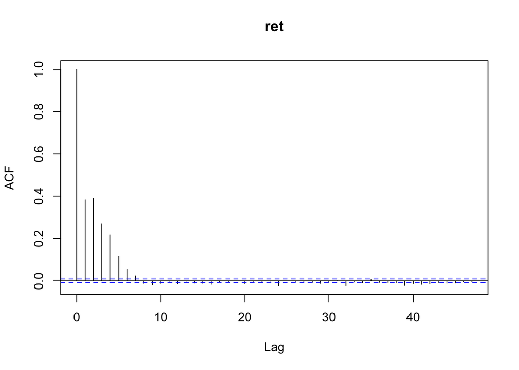

```r
#Creating a series for returns
acf_data <- daily_data %>%
  pivot_longer(!date,names_to = "ticker",values_to = "ret") #pivot longer to make calculations easier

#ACF function for returns
acf_data %>%
  select(ret) %>%
  acf()
```

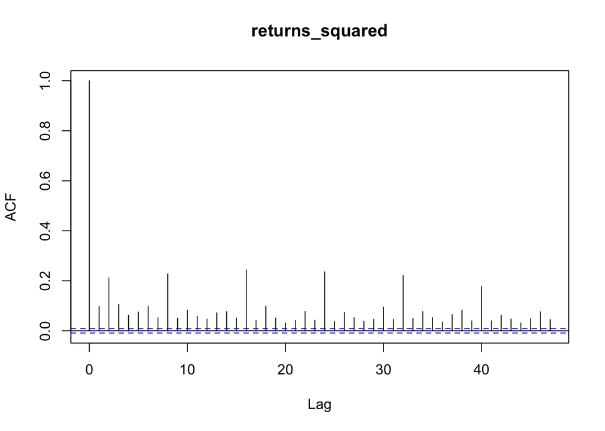

```r
#ACF for returns squared
acf_data %>%
  mutate(returns_squared = ret ** 2) %>%
  select(returns_squared) %>%
  acf()
```

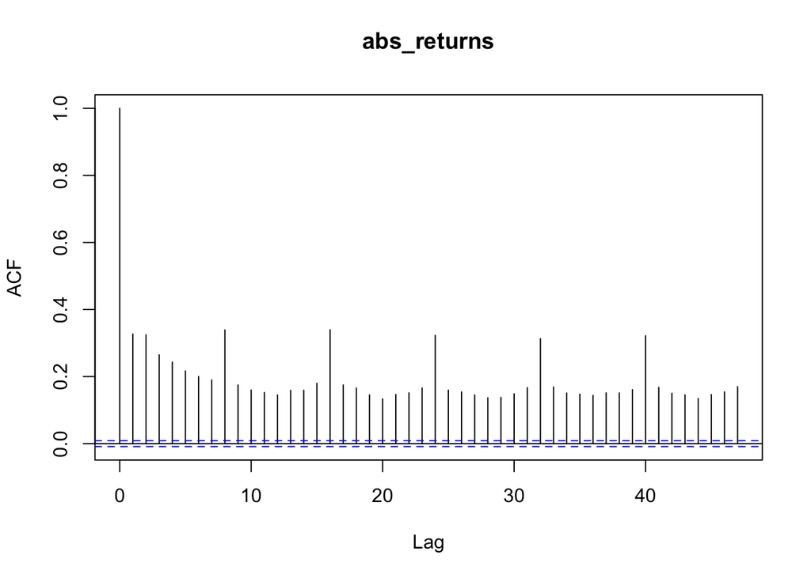

```r
#ACF for absolute returns
acf_data %>%
  mutate(abs_returns = abs(ret)) %>%
  select(abs_returns) %>%
  acf()
```

The autocorrelation with lag 0 in each ACF plot is equal to 1 as this represents the autocorrelation between each term and itself.

From the first ACF plot of returns, we can note that there is a statistically significant correlation for lags up to 7. This means that when the returns are high, they tend to continue rising for upto 7 days and when the returns are low, they tend to be low for upto 7 days.

The second ACF plot of squared returns shows that there is seasonality in the data. For almost every 8 lag values, the correlation becomes statistically significant. This means that there is a positive linear relationship between the squared returns on days which are approximately 8 days apart.

The third ACF plot shows a very strong autocorrelation between absolute returns as the correlation with lag values upto 45 are statistically significant. Seasonality can also be observed from the data as there is a spike in autocorrelation for every 8th day. This means that the value of absolute returns has a positive relationship with its past values, with a specially positive relationship with days having a lag value of 8 or its multiples.

# Question 11

Now, we’ll make up a portfolio with the three stocks we chose above. We’re assigning arbitrary weights to them.

```r
#Selecting the 3 stocks
portfolio_data <- daily_data %>%
  select(date, msft, ge, jpm)

#Assigning weights arbitrarily
w_msft = 0.4
w_ge = 0.2
w_jpm = 0.4

#Create portfolio
portfolio_data <- portfolio_data %>%
  mutate(
    portfolio_returns = 1 + ((w_msft * msft) + (w_ge * ge) + (w_jpm * jpm))
  )
```

By keeping the stock weights set over time, we are not accounting for changes in stock prices. If one particular stock soars over time, it would make sense to sell some of those high-performing stocks, locking in that profit and returning the balance of the portfolio to its original weights. However, our portfolio as is does not account for stock price fluctuations.

Therefore, our portfolio is not taking advantage of the growth of certain stocks, as more weight could be allocated to historically high growth stocks that exhibit higher returns (and volatility). For example, if msft stock is undervalued and shows growth prospects, it would make sense to allocate more portfolio weight to it. On the other hand, in a bear market, if stock prices become volatile, it would make sense to allocate more portfolio weight to stocks with less variance that have shown steady returns over time and no large plunges in price.

# Question 12

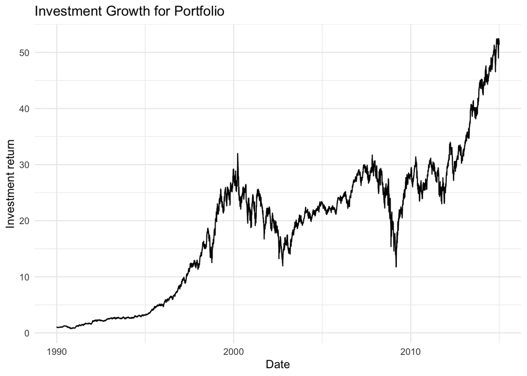

```r
#Investment growth of $1
portfolio_data <- portfolio_data %>%
  mutate(
    #Cumulative product of returns
    investment_growth = cumprod(portfolio_returns)
  )

#Plot of investment growth
portfolio_data %>%
  ggplot() +
  geom_line(aes(x= date, y=investment_growth)) +
  theme_minimal()+
  labs(
    title="Investment Growth for Portfolio",
    y="Investment return",
    x="Date"
  )
```

Overall, we see an upward trend in our portfolio returns, with two dips around 2003 and 2008/9.

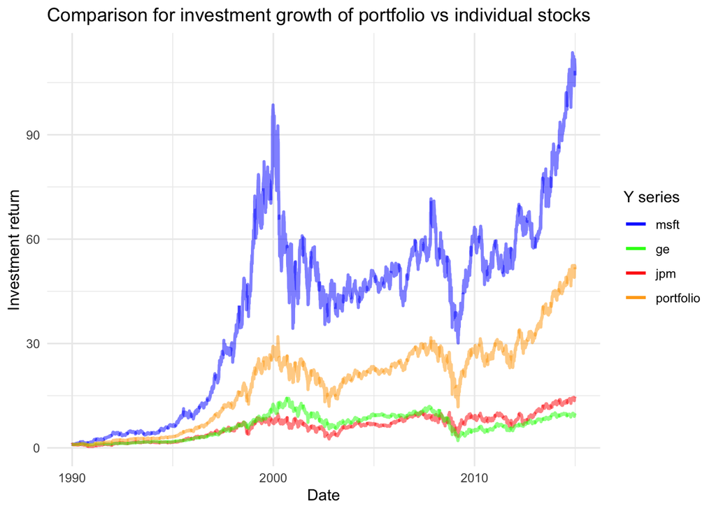

```r
#Calculate needed returns
return_data <- daily_data %>%
  #Selecting relevant columns
  select(c(date, msft, jpm, ge))  %>%
  #Calculating returns
  mutate(msft_ret = msft + 1,
         inv_msft = cumprod(msft_ret),
         ge_ret = ge +1,
         inv_ge = cumprod(ge_ret),
         jpm_ret = jpm +1,
         inv_jpm = cumprod(jpm_ret)) %>%
  select(date, inv_msft, inv_ge, inv_jpm)

#Joining data of individual stocks with portfolio
comparison_data <- return_data %>%
  inner_join(portfolio_data %>% select(date, investment_growth), by = "date")

#Plotting returns for all
comparison_data %>%
  ggplot() +
  geom_line(aes(x= date, y=inv_msft, color="msft"), alpha = 0.5, size = 1)+
  geom_line(aes(x= date, y=inv_jpm, color="jpm"), alpha = 0.5, size = 1)+
  geom_line(aes(x= date, y=inv_ge, color="ge"),alpha = 0.5, size = 1)+
  geom_line(aes(x= date, y=investment_growth, color="portfolio"),alpha = 0.5, size = 1)+
  theme_minimal()+
  labs(
    title="Comparison for investment growth of portfolio vs individual stocks",
    y="Investment return",
    x="Date"
  )+
  scale_color_manual(name = "Y series", values = c("msft" = "blue", "ge" = "green","jpm"="red", "portfolio"="orange"))
```

Plotting our portfolio returns with the individual stock returns over time, we notice several things. By creating a portfolio, we’ve generated more return than if we had invested in GE and JPM alone. However, we’ve created less value than if we had invested solely in MSFT.